# Project 1 JSON

Dexter McNutt

Oct 18, 2019

# JSON What is it?

JSON is a completely language dependent data interchange format that stands for “JavaScript Object Notation” and it is the most widely used data format for data interchange on the web. It’s a great way to store data because it’s based on a subset of the JavaScript programming language making it easy to understand.

Info found here: https://www.geeksforgeeks.org/parse-json-java/

# Using the jsonlite Package

The `JSONLITE` package is simple and has a pretty straightforward syntax and is one of the most widely used packages in R. It also makes saving a data frame in JSON and turning a data frame into a ‘flat’ JSON file very easy making it a naturally choice.

# The Data

I found a dataset that lists and ranks, based on counts, the most popular baby names. I found the data as open source on data.gov. The variables are the year of birth (birthyear), gender(sex), ethnicity(ethnicity), childs first name(first_name), count(count), and the rank of the name (rank).

## Reading it in

As you can see the `fromJSON()` function in the jsonlite package does a good job of pulling in the data but a little help is needed seperating out the metadata. Some options the `fromJSON()` function has are txt (a JSON string, URL, or file), simplifyVector/simplifyDataFrame/simplifyMatrix (coerce JSON arrays into a vector, data frame, or matrix respectively), and flatten (automatically flatten nested data frames into a single non-nested data frame) just to name a few.

Baby Name Data

| birthyear | sex | ethnicity | first_name | count | rank |
| --- | --- | --- | --- | --- | --- |
| 2016 | FEMALE | ASIAN AND PACIFIC ISLANDER | Olivia | 172 | 1 |
| 2016 | FEMALE | ASIAN AND PACIFIC ISLANDER | Chloe | 112 | 2 |
| 2016 | FEMALE | ASIAN AND PACIFIC ISLANDER | Sophia | 104 | 3 |
| 2016 | FEMALE | ASIAN AND PACIFIC ISLANDER | Emma | 99 | 4 |
| 2016 | FEMALE | ASIAN AND PACIFIC ISLANDER | Emily | 99 | 4 |

## Contingency Tables

Here you can see I had to combine a few levels of the column ethnicity:

```r
levels(babyNamesfinal$ethnicity)
```

```
## [1] "ASIAN AND PACI"             "ASIAN AND PACIFIC ISLANDER"
## [3] "BLACK NON HISP"             "BLACK NON HISPANIC"
## [5] "HISPANIC"                   "WHITE NON HISP"
## [7] "WHITE NON HISPANIC"
```

```r
table(kable(babyNamesfinal$ethnicity))
```

```
##
## |:--------------------------| |ASIAN AND PACI             |
##                             1                           693
## |ASIAN AND PACIFIC ISLANDER | |BLACK NON HISP             |
##                          2693                           681
## |BLACK NON HISPANIC         | |HISPANIC                   |
##                          2826                          5714
## |WHITE NON HISP             | |WHITE NON HISPANIC         |
##                          1338                          5473
## |x                          |
##                             1
```

```r
levels(babyNamesfinal$ethnicity) <- c("ASIAN AND PACI","ASIAN AND PACI","BLACK NON HISP","BLACK NON HISP","HISPANIC","WHITE NON HISP", "WHITE NON HISP")

ftable(kable(babyNamesfinal$ethnicity))
```

```
##  |:--------------| |ASIAN AND PACI | |BLACK NON HISP | |HISPANIC       | |WHITE NON HISP | |x              |
##
##                  1              3386              3507              5714              6811                 1
```

```r
levels(babyNamesfinal$ethnicity)
```

```
## [1] "ASIAN AND PACI" "BLACK NON HISP" "HISPANIC"       "WHITE NON HISP"
```

## Bar Charts

So if we look at a highly ranked names "“Olivia”" and "“Jordan”" on the list we can see how popular these names are based on gender:

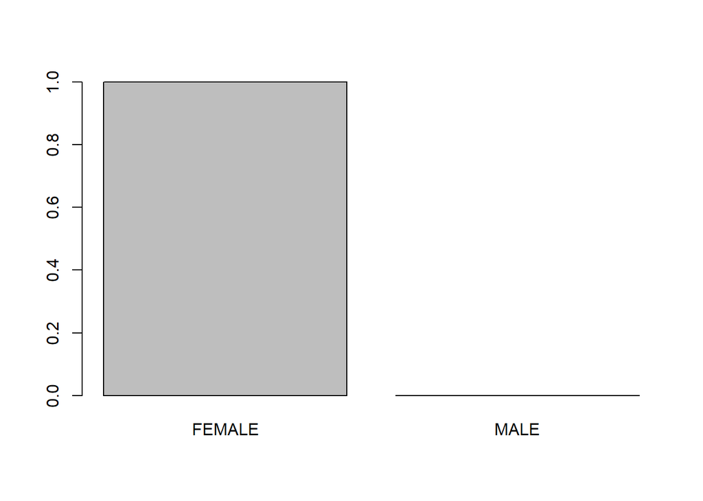

```r
sex1 <- babyNamesfinal$sex[babyNamesfinal$first_name=="Olivia"]
sex2 <- babyNamesfinal$sex[babyNamesfinal$first_name=="Jordan"]

# Number of Male and Female uses of the name Olivia
barplot(prop.table(table(sex1)))
```

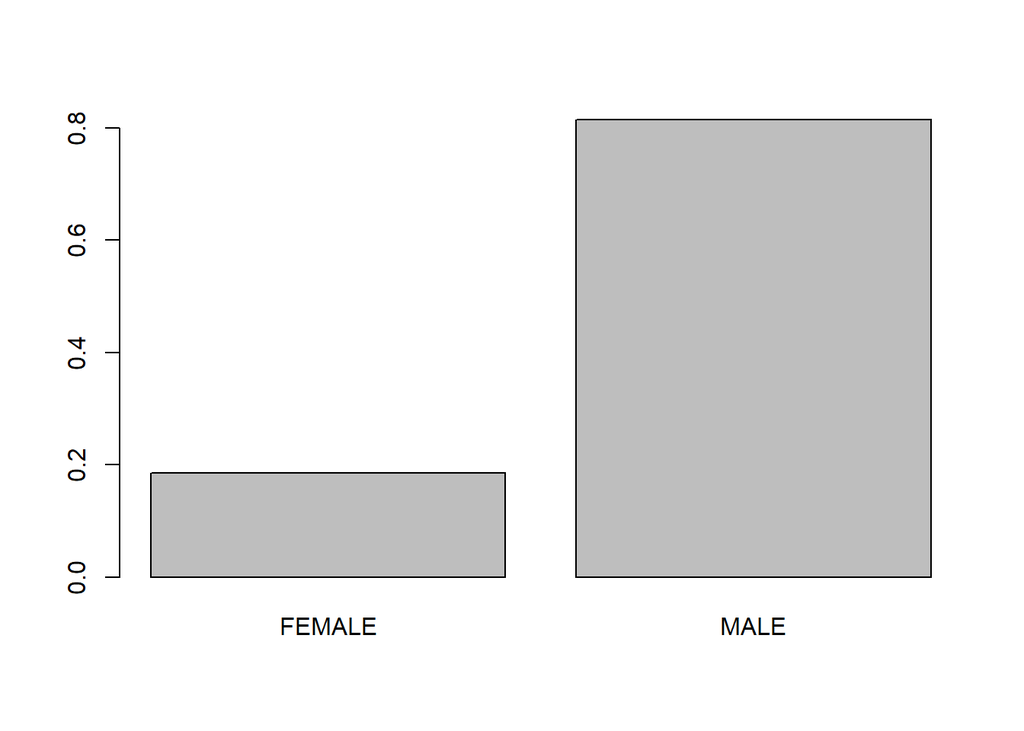

```r
# Number of Male and Female uses of the name Jordan
barplot(prop.table(table(sex2)))
```

## Boxplots and Scatterplots

[figure not shown]

```r
# Simple Scatterplot
attach(babyNamesfinal)
boxplot(as.numeric(count)~as.numeric(rank), main="Box Plots",
   xlab="Ethnicity", ylab="Count")
```

[figure not shown]

```r
# Simple Scatterplot
attach(babyNamesfinal)
plot(count, rank, main="Scatterplot Example",
   xlab="Count", ylab="Rank", pch=19)
```